# JLC245 Project 3

Melanie Klein

2025-05-06

# Data

The American Community Survey (ACS), conducted by the U.S. Census Bureau, collects detailed information on social, economic, housing, and demographic characteristics across a wide range of geographic areas. The 2023 5-year ACS includes data collected from 2019 to 2023, covering 28,261 variables across 935 metropolitan statistical areas (MSAs). Unlike the decennial census, which captures a snapshot every ten years, the ACS is conducted continuously, providing updated estimates annually.

# Methods

The U.S. Census Bureau’s API was used to retrieve data from the 2023 5-year ACS, focusing on all MSAs. Data was accessed and processed to create a reference table cataloging all variables and their definitions, as well as totals for variables. Queries were written for the following variables of interest: total population, median household income, number of bachelor’s degrees, number of people below the poverty line, total population under age 18, number of families with one earner, number of families with two earners, average travel time to work, number of households without a computer, and monthly cost of housing. For each selected variable, MSAs were ranked based on their difference from the Washington, D.C. MSA, and the top ten were identified. MSAs appearing in the top ten across multiple variables were highlighted to reveal similarities to Washington, D.C.

# Analysis

## City 1: San Francisco, CA

San Francisco is the major city within the San Francisco-Oakland-Fremont, CA Metro Area.

San Francisco, CA is similar to Washington, D.C. based on the median household income and the number of people with monthly housing costs greater than $3,000.

Specifically, the median household income in San Francisco is $133,780—only $9,884 higher than the $123,896 median in Washington, D.C. Among all MSAs, San Francisco’s median household income is the fourth closest to that of Washington, D.C.

Regarding housing costs, 712,499 people in San Francisco pay more than $3,000 per month—just 126,139 more than the 586,360 people who do so in Washington, D.C. San Francisco has the second closest number of people in this category among all MSAs compared to Washington, D.C.

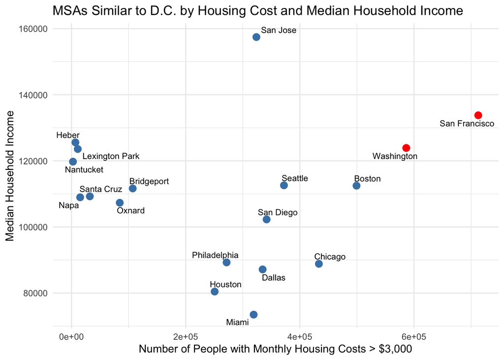

## City 2: Philadelphia, PA

Philadelphia is the major city within the Philadelphia-Camden-Wilmington, PA-NJ-DE-MD Metro Area.

Philadelphia, PA is similar to Washington, D.C. based on the total population and the number of families with one earner.

Specifically, the total population of Philadelphia is 6,241,882—only 21,914 fewer people than the 6,263,796 residents of Washington, D.C. Among all MSAs, Philadelphia’s population is the closest to that of Washington, D.C.

In terms of families with one earner, 470,592 families in Philadelphia fall into this category—just 53,626 more than the 416,966 families with one earner in Washington, D.C. Philadelphia has the second closest number of such families compared to Washington, D.C. among all MSAs.

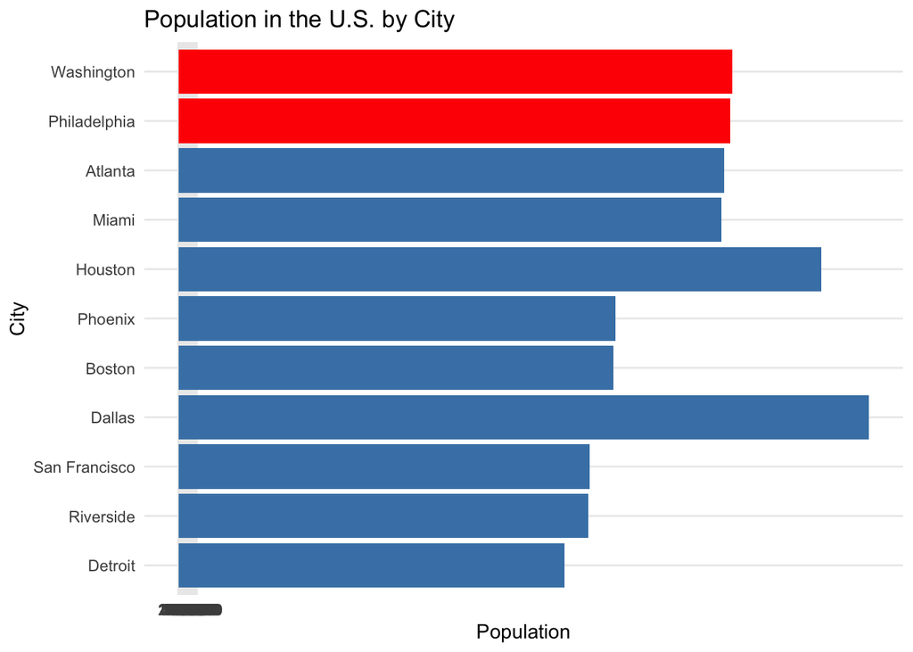

## City 3: Dallas, TX

Dallas is the major city within the Dallas-Fort Worth-Arlington, TX Metro Area.

Dallas, TX is similar to Washington, D.C. based on the number of people over age 25 with a Bachelor’s Degree and the number of families with two earners.

Specifically, 1,968,490 people over age 25 in Dallas hold a Bachelor’s degree—only 346,199 fewer than the 2,314,689 in Washington, D.C. This represents 25.21% of Dallas’s population, compared to 36.95% in Washington, D.C.

Regarding the number of families with two earners, 871,814 families in Dallas have two earners—just 150,865 more than the 720,949 families in Washington, D.C. Among all MSAs, Dallas has the fifth closest number of families in this category compared to Washington, D.C.

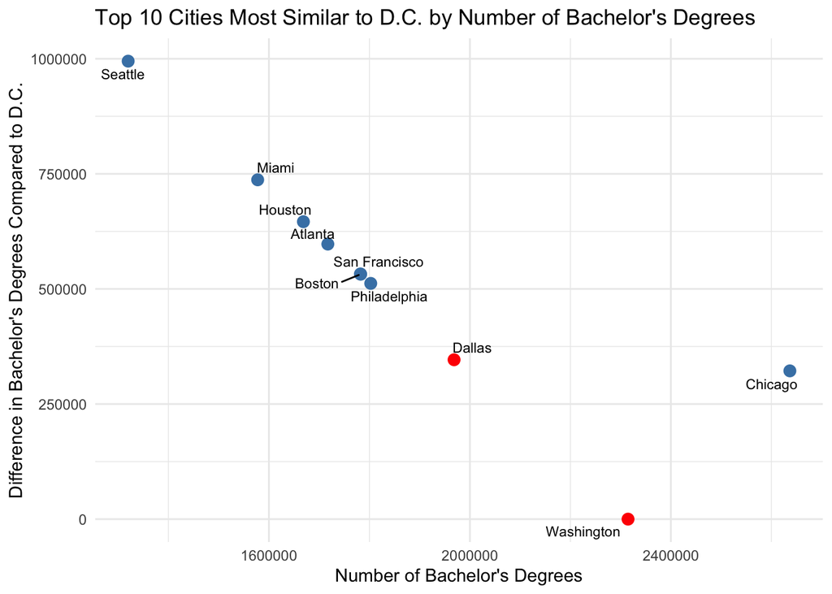

## City 4: Phoenix, AZ

Phoenix is the major city within the Phoenix-Mesa-Chandler, AZ Metro Area.

Phoenix, AZ is similar to Washington, D.C. based on the number of families whose income is less than 50 percent of the poverty level and the number of households without a computer.

Specifically, 44,618 families in Phoenix fall below 50 percent of the poverty level—only 5,231 more than the 39,387 families in Washington, D.C. Among all MSAs, Phoenix has the second closest number of families in this category compared to Washington, D.C.

Regarding households without a computer, 58,664 in Phoenix lack one—just 790 fewer than the 59,454 households in Washington, D.C. Among all MSAs, Phoenix has the closest number of households without a computer compared to Washington, D.C.

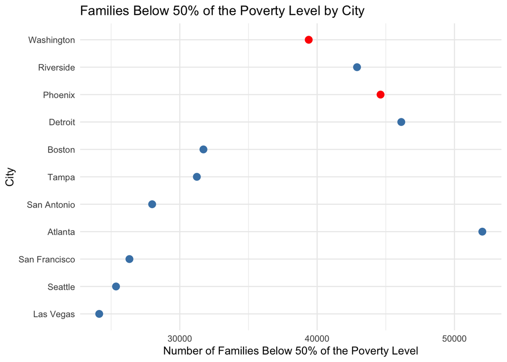

## City 5: Atlanta, GA

Atlanta is the major city within the Atlanta-Sandy Springs-Roswell, GA Metro Area.

Atlanta, GA is similar to Washington, D.C. based on the population under age 18 and the number of people whose travel time to work is less than five minutes.

Specifically, 1,473,173 people in Atlanta are under age 18—only 40,306 more than the 1,432,867 in Washington, D.C. This represents 23.85% of Atlanta’s population, compared to 22.88% in Washington, D.C. Among all MSAs, Atlanta has the closest number of youth compared to Washington, D.C.

Regarding travel time to work, 41,782 people in Atlanta commute in less than five minutes—just 4,095 more than the 37,687 people in Washington, D.C. Among all MSAs, Atlanta has the fourth closest number of people with this commute time compared to Washington, D.C.

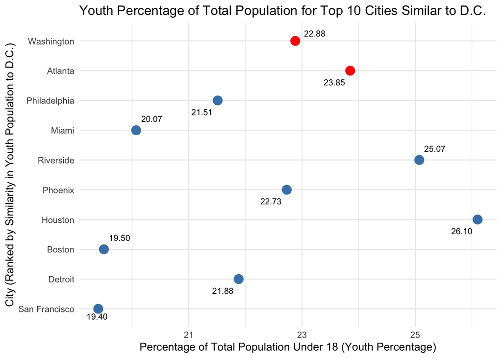